# Practical Machine Learning: PML1

Marc Borowczak

2015-05-18

### System and platform documentation

Before any analysis is performed, let’s start with system and platform documentation in a fresh directory to insure reproducibility.

```r
Sys.info()[1:5]                         # system info but exclude login and user info
```

```
##                      sysname                      release
##                    "Windows"                      "7 x64"
##                      version                     nodename
## "build 7601, Service Pack 1"                   "STALLION"
##                      machine
##                     "x86-64"
```

```r
userdir<-getwd()                        # user-defined startup directory
library(plyr)
library(dplyr)                          # provides data manipulating functions
library(ggplot2)                        # for graphics
library(GGally)
library(caret)
library(rpart)
library(rattle)
```

### Loading and pre-processing

*Error in download.file(url, dest = filename, mode = “wb”) : unsupported URL scheme*

*Note also that R studio can handle https on the same binary file without error.*

The data files are uploaded directly in the /data subdirectory with non-secured http protocol from the corresponding urls and populate the data frames pml.training and pml.tetsing.

```r
datadir<-"./data" ; if (!file.exists("data")) { dir.create("data") } # data will reside in subdir
url <- "http://d396qusza40orc.cloudfront.net/predmachlearn/pml-training.csv"
filename <- paste(datadir,strsplit(url,"/")[[1]][length(strsplit(url,"/")[[1]])],sep="/")
download.file(url, dest=filename, mode="wb")
pml.training <- read.csv(filename,header=TRUE,stringsAsFactors=FALSE)       # populate data frame
url <- "http://d396qusza40orc.cloudfront.net/predmachlearn/pml-testing.csv"
filename <- paste(datadir,strsplit(url,"/")[[1]][length(strsplit(url,"/")[[1]])],sep="/")
download.file(url, dest=filename, mode="wb")
pml.testing <- read.csv(filename,header=TRUE,stringsAsFactors=FALSE)       # populate data frame
```

### Supporting Function

To ease submittal of trained answers, we include the function to populate answers as a character vector with 20 elements provided.

```r
pml_write_files = function(x,y){
        n = length(x)
        for(i in 1:n){
                filename = paste0("problem_id_",i,".txt")
                filename = paste(outdir,filename,sep="/")
                write.table(x[i],file=filename,quote=FALSE,row.names=FALSE,col.names=FALSE)
        }
}
```

### Initial Data Trimming and Plotting

We perform all trimming on copies of the dataframes dftrain and will perform similar trimming in dftest. Since all information is originally contained only in the raw data and we observe the stats data (min, max, total ,kurtosis, skewness, avg, std, var and amplitude) are mostly absent, we retain only the 12 raw-data variables (roll, pitch, yaw, (x,y,z)gyros, (x,y,z)accel and (x,y,z)magnet) for each location (belt, arm, dumbell and forearm) and the classe outcome. We also exclude the index X, user_name, and timestamping and window variables. This data trimming is performed systematically, using grep, as detailed:

```r
dftrain<-pml.training
flag<-NULL
flag<-c(flag,grep("^max",colnames(dftrain),value=TRUE))
flag<-c(flag,grep("^min",colnames(dftrain),value=TRUE))
flag<-c(flag,grep("^total",colnames(dftrain),value=TRUE))
flag<-c(flag,grep("^kurtosis",colnames(dftrain),value=TRUE))
flag<-c(flag,grep("^skewness",colnames(dftrain),value=TRUE))
flag<-c(flag,grep("^avg",colnames(dftrain),value=TRUE))
flag<-c(flag,grep("^stddev",colnames(dftrain),value=TRUE))
flag<-c(flag,grep("^var",colnames(dftrain),value=TRUE))
flag<-c(flag,grep("^amplitude",colnames(dftrain),value=TRUE))
dftrain<-dftrain[, !(names(dftrain) %in% flag)]
dftrain$classe<-as.factor(dftrain$classe)
dftrain$user_name<-as.factor(dftrain$user_name)
g0<-qplot(data=dftrain,X,classe,colour=user_name)
```

In order to visualize this data we simply chart…

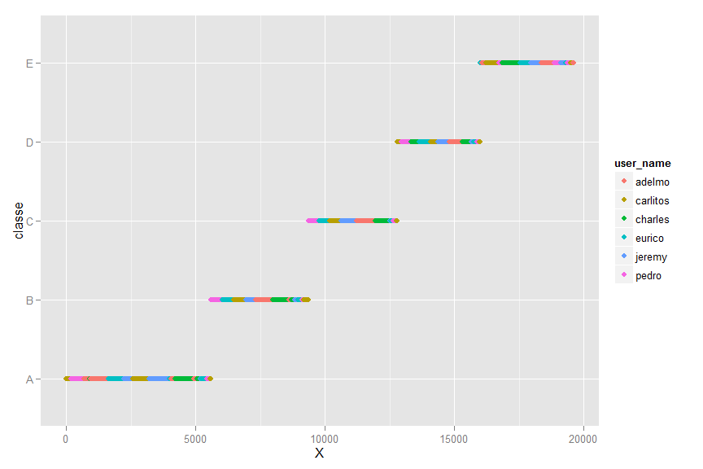

Fig1. Data sampling

```r
2*sum(dftrain$X)/nrow(dftrain)  # no info in X except line #, so can skip in model
```

```
## [1] 19623
```

```r
M <- abs(cor(dftrain[,c(-1,-2,-3,-4,-5,-6,-56)]))
diag(M) <- 0
which(M > 0.8,arr.ind=T) # these variables appear not too correlated
```

```
##                  row col
## yaw_belt           4   2
## accel_belt_y       9   2
## accel_belt_z      10   2
## accel_belt_x       8   3
## magnet_belt_x     11   3
## roll_belt          2   4
## pitch_belt         3   8
## magnet_belt_x     11   8
## roll_belt          2   9
## accel_belt_z      10   9
## roll_belt          2  10
## accel_belt_y       9  10
## pitch_belt         3  11
## accel_belt_x       8  11
## gyros_arm_y       18  17
## gyros_arm_x       17  18
## magnet_arm_x      23  20
## accel_arm_x       20  23
## magnet_arm_z      25  24
## magnet_arm_y      24  25
## accel_dumbbell_x  32  27
## accel_dumbbell_z  34  28
## gyros_dumbbell_z  31  29
## gyros_forearm_z   43  29
## gyros_dumbbell_x  29  31
## gyros_forearm_z   43  31
## pitch_dumbbell    27  32
## yaw_dumbbell      28  34
## gyros_forearm_z   43  42
## gyros_dumbbell_x  29  43
## gyros_dumbbell_z  31  43
## gyros_forearm_y   42  43
```

```r
keep<-row.names(M);keep=c("user_name",keep,"classe")
dftrain<-dftrain[,(names(dftrain)) %in% keep]
dftrain<-dftrain[,-c(1,2)] # do not retain user_name nor num_window for training
```

Now transform the test data set similarly than the training set…

```r
dftest<-pml.testing
dftest<-dftest[, !(names(dftest) %in% flag)]
dftest$user_name<-as.factor(dftest$user_name)
keep<-keep[c(-1,-2,-51)] # note we do not have classe in the testing set
dftest<-dftest[,(names(dftest)) %in% keep]
```

### Generating Plots

```r
g1<-ggpairs(dftrain[,c( 1:12,49)],title="Belt Sensor Data",lower=list(continuous="smooth"),params=c(method="loess"),upper=list(params=list(corSize=6)),axisLabels='show')
g2<-ggpairs(dftrain[,c(13:24,49)],title="Arm Sensor Data",lower=list(continuous="smooth"),params=c(method="loess"),upper=list(params=list(corSize=6)),axisLabels='show')
g3<-ggpairs(dftrain[,c(25:36,49)],title="Dumbell Sensor Data",lower=list(continuous="smooth"),params=c(method="loess"),upper=list(params=list(corSize=6)),axisLabels='show')
g4<-ggpairs(dftrain[,c(37:48,49)],title="Forearm Sensor Data",lower=list(continuous="smooth"),params=c(method="loess"),upper=list(params=list(corSize=6)),axisLabels='show')
```

We illustrate for the Belt location… Other locations yield similar patterns.

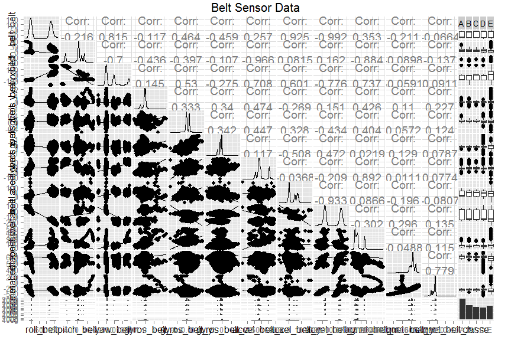

Fig.2 Belt sensor Data Pairwise Analysis

### Training

After setting seed (to enable reproducible outcome), start Machine training and perform sequentially 3 models (RPart, RF and GBM). The only pre-processing steps are to center and scale the data. The output is written to the respective subdirectories.

```r
set.seed(12321)
modelFit0 <- train(classe ~.,data=dftrain,preProcess=c("center","scale"),method="rpart")
modelFit0
```

```
## CART
##
## 19622 samples
##    48 predictor
##     5 classes: 'A', 'B', 'C', 'D', 'E'
##
## Pre-processing: centered, scaled
## Resampling: Bootstrapped (25 reps)
##
## Summary of sample sizes: 19622, 19622, 19622, 19622, 19622, 19622, ...
##
## Resampling results across tuning parameters:
##
##   cp          Accuracy   Kappa       Accuracy SD  Kappa SD
##   0.03567868  0.5190500  0.37826058  0.02707339   0.04476758
##   0.05998671  0.4132557  0.20280938  0.06225177   0.10442458
##   0.11515454  0.3203298  0.05431703  0.04155111   0.06259096
##
## Accuracy was used to select the optimal model using  the largest value.
## The final value used for the model was cp = 0.03567868.
```

```r
print(modelFit0$finalModel)
```

```
## n= 19622
##
## node), split, n, loss, yval, (yprob)
##       * denotes terminal node
##
##  1) root 19622 14042 A (0.28 0.19 0.17 0.16 0.18)
##    2) roll_belt< 1.053267 17977 12411 A (0.31 0.21 0.19 0.18 0.11)
##      4) pitch_forearm< -1.58661 1578    10 A (0.99 0.0063 0 0 0) *
##      5) pitch_forearm>=-1.58661 16399 12401 A (0.24 0.23 0.21 0.2 0.12)
##       10) magnet_dumbbell_y< 0.6685762 13870  9953 A (0.28 0.18 0.24 0.19 0.11)
##         20) roll_forearm< 0.8300342 8643  5131 A (0.41 0.18 0.18 0.17 0.061) *
##         21) roll_forearm>=0.8300342 5227  3500 C (0.077 0.18 0.33 0.23 0.18) *
##       11) magnet_dumbbell_y>=0.6685762 2529  1243 B (0.032 0.51 0.043 0.22 0.19) *
##    3) roll_belt>=1.053267 1645    14 E (0.0085 0 0 0 0.99) *
```

Now let’s display the tree…

[figure not shown]

Fig 3. Rattle Output

And predict with ModelFit0, output predicted values to outdir…

```r
pred0<-predict(modelFit0,dftest);
outdir<-"./RPart_output";if (!file.exists("RPart_output")) { dir.create("RPart_output") } # RPart_output will reside in subdir
pml_write_files(pred0,outdir)
```

We observe this model is quick but accuracy is very low…with RPart method, so we try Random Forest method training…

```r
modelFit1 <- train(classe ~.,data=dftrain,preProcess=c("center","scale"),method="rf",verbose=TRUE)
modelFit1
```

```
## Random Forest
##
## 19622 samples
##    48 predictor
##     5 classes: 'A', 'B', 'C', 'D', 'E'
##
## Pre-processing: centered, scaled
## Resampling: Bootstrapped (25 reps)
##
## Summary of sample sizes: 19622, 19622, 19622, 19622, 19622, 19622, ...
##
## Resampling results across tuning parameters:
##
##   mtry  Accuracy   Kappa      Accuracy SD   Kappa SD
##    2    0.9926412  0.9906919  0.0011853128  0.001500732
##   25    0.9926163  0.9906604  0.0009757748  0.001237346
##   48    0.9843230  0.9801691  0.0035939594  0.004549437
##
## Accuracy was used to select the optimal model using  the largest value.
## The final value used for the model was mtry = 2.
```

```r
print(modelFit1$finalModel)
```

```
##
## Call:
##  randomForest(x = x, y = y, mtry = param$mtry, verbose = TRUE)
##                Type of random forest: classification
##                      Number of trees: 500
## No. of variables tried at each split: 2
##
##         OOB estimate of  error rate: 0.39%
## Confusion matrix:
##      A    B    C    D    E  class.error
## A 5579    1    0    0    0 0.0001792115
## B    9 3785    3    0    0 0.0031603898
## C    0   15 3405    2    0 0.0049678551
## D    0    0   37 3177    2 0.0121268657
## E    0    0    0    7 3600 0.0019406709
```

We observe high accuracy (>99.26%) can be achieved but the process is relatively slow. We will do our prediction with ModelFit1 and save in the corresponding outdir.

```r
pred1<-predict(modelFit1,dftest);
outdir<-"./RF_output";if (!file.exists("RF_output")) { dir.create("RF_output") } # RF_output will reside in subdir
pml_write_files(pred1,outdir)
```

Noting RF is very accurate but slow, we also try gbm method, a bit faster.

```r
modelFit2 <- train(classe ~.,data=dftrain,preProcess=c("center","scale"),method="gbm",verbose=FALSE)
modelFit2
```

```
## Stochastic Gradient Boosting
##
## 19622 samples
##    48 predictor
##     5 classes: 'A', 'B', 'C', 'D', 'E'
##
## Pre-processing: centered, scaled
## Resampling: Bootstrapped (25 reps)
##
## Summary of sample sizes: 19622, 19622, 19622, 19622, 19622, 19622, ...
##
## Resampling results across tuning parameters:
##
##   interaction.depth  n.trees  Accuracy   Kappa      Accuracy SD
##   1                   50      0.7508174  0.6840152  0.007124179
##   1                  100      0.8170616  0.7684489  0.004399221
##   1                  150      0.8497242  0.8098445  0.004045949
##   2                   50      0.8544490  0.8155861  0.004930117
##   2                  100      0.9045155  0.8791526  0.003250311
##   2                  150      0.9294421  0.9107062  0.002857224
##   3                   50      0.8946196  0.8665861  0.005083956
##   3                  100      0.9407584  0.9250316  0.002884909
##   3                  150      0.9597806  0.9491127  0.002390879
##   Kappa SD
##   0.009009540
##   0.005544274
##   0.005064980
##   0.006218186
##   0.004100004
##   0.003598491
##   0.006465406
##   0.003644888
##   0.003023170
##
## Tuning parameter 'shrinkage' was held constant at a value of 0.1
## Accuracy was used to select the optimal model using  the largest value.
## The final values used for the model were n.trees = 150,
##  interaction.depth = 3 and shrinkage = 0.1.
```

```r
print(modelFit2$finalModel)
```

```
## A gradient boosted model with multinomial loss function.
## 150 iterations were performed.
## There were 48 predictors of which 37 had non-zero influence.
```

We observe accuracy slightly about 96% so we predict with modelFit2 and save in corresponding outdir.

```r
pred2<-predict(modelFit2,dftest);
outdir<-"./GBM_output";if (!file.exists("GBM_output")) { dir.create("GBM_output") } # GBM_output will reside in subdir
pml_write_files(pred2,outdir)
```

## Model Performance

The best accuracy is observed for the Random Forest algorithm, in excess of 99.2%. We simply indicate output here and predictions, which scored 20/20! To quantify cross-validation errors, we will now repeat 3 times RF and average the accuracy to estimate the errors:

```r
Results<-data.frame()
Results<-modelFit1$results$Accuracy
modelFit1A <- train(classe ~.,data=dftrain,preProcess=c("center","scale"),method="rf",verbose=TRUE)
modelFit1A;print(modelFit1A$finalModel);pred1A<-predict(modelFit1A,dftest);
```

```
## Random Forest
##
## 19622 samples
##    48 predictor
##     5 classes: 'A', 'B', 'C', 'D', 'E'
##
## Pre-processing: centered, scaled
## Resampling: Bootstrapped (25 reps)
##
## Summary of sample sizes: 19622, 19622, 19622, 19622, 19622, 19622, ...
##
## Resampling results across tuning parameters:
##
##   mtry  Accuracy   Kappa      Accuracy SD  Kappa SD
##    2    0.9931681  0.9913561  0.001442310  0.001825523
##   25    0.9926927  0.9907545  0.001451478  0.001838036
##   48    0.9860879  0.9823972  0.004187191  0.005300991
##
## Accuracy was used to select the optimal model using  the largest value.
## The final value used for the model was mtry = 2.
```

```
##
## Call:
##  randomForest(x = x, y = y, mtry = param$mtry, verbose = TRUE)
##                Type of random forest: classification
##                      Number of trees: 500
## No. of variables tried at each split: 2
##
##         OOB estimate of  error rate: 0.41%
## Confusion matrix:
##      A    B    C    D    E  class.error
## A 5579    1    0    0    0 0.0001792115
## B   15 3778    4    0    0 0.0050039505
## C    0   16 3404    2    0 0.0052600818
## D    0    0   34 3181    1 0.0108830846
## E    0    0    0    7 3600 0.0019406709
```

```r
Results<-c(Results,modelFit1A$results$Accuracy)
modelFit1B <- train(classe ~.,data=dftrain,preProcess=c("center","scale"),method="rf",verbose=TRUE)
modelFit1B;print(modelFit1B$finalModel);pred1B<-predict(modelFit1B,dftest);
```

```
## Random Forest
##
## 19622 samples
##    48 predictor
##     5 classes: 'A', 'B', 'C', 'D', 'E'
##
## Pre-processing: centered, scaled
## Resampling: Bootstrapped (25 reps)
##
## Summary of sample sizes: 19622, 19622, 19622, 19622, 19622, 19622, ...
##
## Resampling results across tuning parameters:
##
##   mtry  Accuracy   Kappa      Accuracy SD   Kappa SD
##    2    0.9933910  0.9916372  0.0009476264  0.001200981
##   25    0.9928474  0.9909497  0.0010278413  0.001301272
##   48    0.9854704  0.9816143  0.0035482330  0.004492288
##
## Accuracy was used to select the optimal model using  the largest value.
## The final value used for the model was mtry = 2.
```

```
##
## Call:
##  randomForest(x = x, y = y, mtry = param$mtry, verbose = TRUE)
##                Type of random forest: classification
##                      Number of trees: 500
## No. of variables tried at each split: 2
##
##         OOB estimate of  error rate: 0.4%
## Confusion matrix:
##      A    B    C    D    E  class.error
## A 5576    3    0    0    1 0.0007168459
## B    9 3785    3    0    0 0.0031603898
## C    0   16 3404    2    0 0.0052600818
## D    0    0   38 3176    2 0.0124378109
## E    0    0    0    4 3603 0.0011089548
```

```r
Results<-c(Results,modelFit1B$results$Accuracy)
summary(Results)
```

```
##    Min. 1st Qu.  Median    Mean 3rd Qu.    Max.
##  0.9843  0.9861  0.9926  0.9904  0.9928  0.9934
```

```r
var(Results)
```

```
## [1] 1.470015e-05
```

The predictions from these RF trained sets are:

```r
modelFit1
```

```
## Random Forest
##
## 19622 samples
##    48 predictor
##     5 classes: 'A', 'B', 'C', 'D', 'E'
##
## Pre-processing: centered, scaled
## Resampling: Bootstrapped (25 reps)
##
## Summary of sample sizes: 19622, 19622, 19622, 19622, 19622, 19622, ...
##
## Resampling results across tuning parameters:
##
##   mtry  Accuracy   Kappa      Accuracy SD   Kappa SD
##    2    0.9926412  0.9906919  0.0011853128  0.001500732
##   25    0.9926163  0.9906604  0.0009757748  0.001237346
##   48    0.9843230  0.9801691  0.0035939594  0.004549437
##
## Accuracy was used to select the optimal model using  the largest value.
## The final value used for the model was mtry = 2.
```

```r
pred1;pred1A;pred1B
```

```
##  [1] B A B A A E D B A A B C B A E E A B B B
## Levels: A B C D E
```

```
##  [1] B A B A A E D B A A B C B A E E A B B B
## Levels: A B C D E
```

```
##  [1] B A B A A E D B A A B C B A E E A B B B
## Levels: A B C D E
```

## Conclusions

This machine learning example shows potential of the RF algorithm, to predict activity from learned sensor data with exceptional accuracy, but also required heavy CPU time.

### References

1. Wearable Computing Accelerometer’s Data Classification of Body Postures and Movements (Wallace Ugulino, et al, 08-22-2012 [link] (http://groupware.les.inf.puc-rio.br/har)
2. Coursera. Practical Machine Learning [link] (https://www.coursera.org/course/predmachlearn) part of Data Science Specialization Track [link] (https://www.coursera.org/specialization/jhudatascience/1?utm_medium=courseDescripTop)